# Changing established atttiudes via the IAT: Experiment 2

Ian Hussey

Conceptual replication of Experiment 1. Employs AMP as DV rather than SC-IAT.

```r
knitr::opts_chunk$set(message=FALSE,
                      warning=FALSE,
                      cache.lazy=FALSE)
```

```r
# dependencies
library(tidyverse)
library(psych)
library(weights)  # for rd(), a round() alternative
library(plotrix)  # for std.error
library(lme4)
library(effects)
library(knitr)
library(kableExtra)
library(sjPlot)
library(apa)

# rounds all numerics in a df
round_df <- function(df, digits) {
  nums <- vapply(df, is.numeric, FUN.VALUE = logical(1))
  df[,nums] <- round(df[,nums], digits = digits)
  (df)
}

# options
options(knitr.table.format = "html") # necessary configuration of tables

# disable scientific notation
options(scipen = 999)
```

# Descriptive statistics

## Full sample

```r
# get data
data_df <-
  read.csv("data/processed/processed summary data - wide format.csv") %>%
  mutate(gender = as.factor(gender))

#colnames(data_df)

attrition_rate <- data_df %>%
  dplyr::summarize(rate = round(sum(exclude)/n()*100, 1)) %>%
  as.numeric()

data_df %>%
  count(exclude) %>%
  kable() %>%
  kable_styling(bootstrap_options = c("striped", "hover", "condensed"), full_width = FALSE)
```

| exclude | n |
| --- | --- |
| FALSE | 213 |
| TRUE | 19 |

```r
chi2_result <- data_df %>%
  count(IAT_condition, exclude) %>%
  spread(exclude, n) %>%
  select(-IAT_condition) %>%
  chisq.test(.) %>%
  chisq_apa(., print_n = TRUE, format = c("rmarkdown"), info = FALSE, print = FALSE)

passers_df <- data_df %>%
  filter(exclude == FALSE)

N <- passers_df %>%
  dplyr::summarize(n = n()) %>%
  as.numeric()

passers_df %>%
  count(AMP_exclude_based_on_fast_trials_old) %>%
  rowwise() %>%
  mutate(percent = round(n/N*100, 1)) %>%
  ungroup() %>%
  kable() %>%
  kable_styling(bootstrap_options = c("striped", "hover", "condensed"), full_width = FALSE)
```

| AMP_exclude_based_on_fast_trials_old | n | percent |
| --- | --- | --- |
| FALSE | 113 | 53.1 |
| TRUE | 100 | 46.9 |

Attrition rate = 8.2%.

A chi squared test was used to assess whether the conditions suffered from differential attrition rates: $\chi^2$(1, n = 232) = 1.64, *p* = .200. [nb results of p = 1.0 will show as = .000 due to an error in how chisq_apa trims its results]

## Analytic sample

I.e., after applying inclusion/exclusion criteria.

### Age

```r
passers_df %>%
  #dplyr::select(age) %>%
  pull(age) %>%
  psych::describe(fast = TRUE,  # subset of descriptive stats
                  ranges = FALSE,
                  trim = 0) %>%
  dplyr::select(-vars, -se) %>%
  kable() %>%
  kable_styling(bootstrap_options = c("striped", "hover", "condensed"), full_width = FALSE)
```

|  | n | mean | sd |
| --- | --- | --- | --- |
| X1 | 213 | 35.81221 | 12.0929 |

### Gender

```r
passers_df %>%
  dplyr::count(gender) %>%
  kable() %>%
  kable_styling(bootstrap_options = c("striped", "hover", "condensed"), full_width = FALSE)
```

| gender | n |
| --- | --- |
|  | 1 |
| fee | 1 |
| female | 99 |
| female | 2 |
| genderfluid | 1 |
| male | 107 |
| male | 1 |
| woman | 1 |

### Performance on the IAT and AMP

```r
passers_df %>%
  dplyr::select(IAT_mean_RT,
                IAT_perc_acc,
                AMP_mean_RT,
                AMP_perc_acc) %>%
  psych::describe(fast = TRUE,  # subset of descriptive stats
                  ranges = FALSE,
                  trim = 0) %>%
  as.data.frame() %>%
  rownames_to_column() %>%
  dplyr::select(-vars, -se) %>%
  mutate(mean = round(mean, 2),
         sd = round(sd, 2)) %>%
  kable() %>%
  kable_styling(bootstrap_options = c("striped", "hover", "condensed"), full_width = FALSE)
```

| rowname | n | mean | sd |
| --- | --- | --- | --- |
| IAT_mean_RT | 213 | 837.23 | 158.79 |
| IAT_perc_acc | 213 | 0.93 | 0.06 |
| AMP_mean_RT | 213 | 543.05 | 194.24 |
| AMP_perc_acc | 213 | 0.65 | 0.21 |

# Hypothesis test 1: Differences in AMP effects between contrast pair conditions

H1: Completing an IAT serves to train attitudes as well as test them. Participants who complete a race IAT will demonstrate more negative implicit evaluations of the outgroup (black people) on the AMP than participants who completed a control (flowers-insects) IAT.

```r
AMP_data <-
  read.csv("data/processed/processed AMP data - long format.csv") %>%
  dplyr::filter(exclude == FALSE,
                IAT_exclude_based_on_fast_trials == FALSE) %>%
  dplyr::mutate(participant = as.factor(participant),
                rating_factor = as.factor(ifelse(accuracy == 0, "negative",
                                                 ifelse(accuracy == 1, "positive", NA))),
                IAT_condition = as.factor(IAT_condition)) %>%
  dplyr::rename(prime_type = item,
                rating = accuracy)

# Check that variables that should be factors are indeed factors
sapply(AMP_data, class)
```

```
##                          participant                               rating
##                             "factor"                            "integer"
##                                   rt                           prime_type
##                            "integer"                             "factor"
##                        IAT_condition                          block_order
##                             "factor"                             "factor"
##                           task_order                               gender
##                             "factor"                             "factor"
##                                  age            modern_racism_scale_total
##                            "integer"                            "integer"
##             amp_recognition_response     IAT_exclude_based_on_fast_trials
##                             "factor"                            "logical"
## AMP_exclude_based_on_fast_trials_old                              exclude
##                            "logical"                            "logical"
##                        rating_factor
##                             "factor"
```

### Plot distribution

Distribution of AMP ratings.

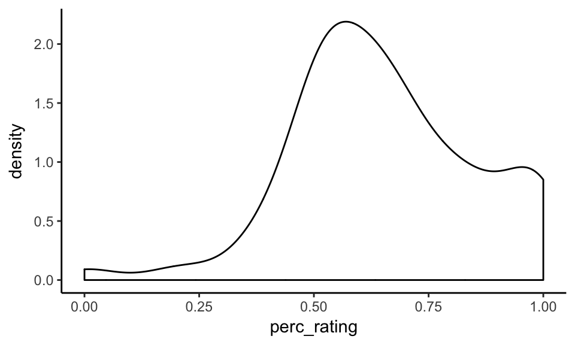

```r
AMP_participant_summary_data <-
  AMP_data %>%
  group_by(participant) %>%
  dplyr::summarize(perc_rating = round(mean(rating), 2))

ggplot(AMP_participant_summary_data,
       aes(perc_rating)) +
  geom_density(alpha=0.50) +
  theme_classic()
```

## Generalised linear mixed model

### Model

```r
# convergence issues with model apparently due to scale of continuous variable, so standardize and center it.
# https://rstudio-pubs-static.s3.amazonaws.com/33653_57fc7b8e5d484c909b615d8633c01d51.html

temp <- AMP_data %>%
  distinct(participant, .keep_all = TRUE) %>%
  mutate(modern_racism_scale_total_scaled = scale(modern_racism_scale_total)) %>%
  select(participant, modern_racism_scale_total_scaled)

AMP_data_mod <- AMP_data %>%
  left_join(temp, by = "participant")

model_1 <- glmer(rating ~ prime_type * IAT_condition + modern_racism_scale_total_scaled + (1 | participant),
                 family = "binomial",
                 contrasts = list(prime_type = "contr.sum",
                                  IAT_condition = "contr.sum"),
                 data = AMP_data_mod)
```

- Hypothesis refers to the IAT_condition*AMP_prime_type interaction effect.

### Summary

```r
sjt.glmer(model_1,
          emph.p = FALSE,
          digits.p = 7)
```

|  |  | rating |  |  |
| --- | --- | --- | --- | --- |
|  |  | Odds Ratio | CI | p |
| Fixed Parts |  |  |  |  |
| (Intercept) |  | 2.46 | 2.01 – 3.00 | .0000000 |
| prime_type1 |  | 1.04 | 1.00 – 1.07 | .0285792 |
| IAT_condition1 |  | 1.12 | 0.91 – 1.36 | .2821887 |
| modern_racism_scale_total_scaled |  | 0.85 | 0.69 – 1.03 | .1032325 |
| prime_type1:IAT_condition1 |  | 0.92 | 0.90 – 0.95 | .0000007 |
| Random Parts |  |  |  |  |
| τ<sub>00, participant</sub> |  | 2.112 |  |  |
| N<sub>participant</sub> |  | 212 |  |  |
| ICC<sub>participant</sub> |  | 0.391 |  |  |
| Observations |  | 21300 |  |  |
| Deviance |  | 22850.634 |  |  |

### Plot effects

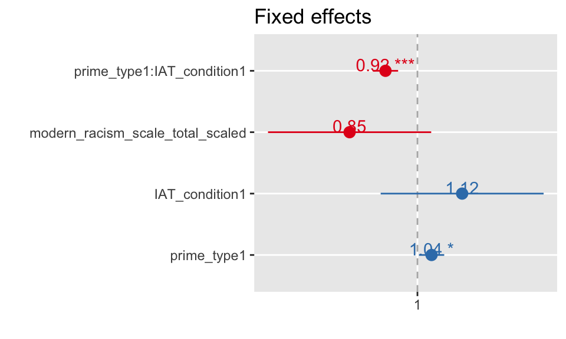

```r
sjp.glmer(model_1,
          type = "fe")
```

### Table predictions

```r
model_1_predicted_effects <-
  as.data.frame(effect("prime_type:IAT_condition", model_1)) %>%
  rename(`IAT condition` = IAT_condition,
         `AMP prime type` = prime_type)

model_1_predicted_effects %>%
  round_df(2) %>%
  kable() %>%
  kable_styling(bootstrap_options = c("striped", "hover", "condensed"), full_width = FALSE)
```

| AMP prime type | IAT condition | fit | se | lower | upper |
| --- | --- | --- | --- | --- | --- |
| primeNeutral | Flowers-Insects IAT | 0.72 | 0.03 | 0.71 | 0.74 |
| primeRace | Flowers-Insects IAT | 0.74 | 0.03 | 0.73 | 0.75 |
| primeNeutral | Race IAT | 0.71 | 0.03 | 0.70 | 0.72 |
| primeRace | Race IAT | 0.66 | 0.03 | 0.65 | 0.68 |

### Plot predictions

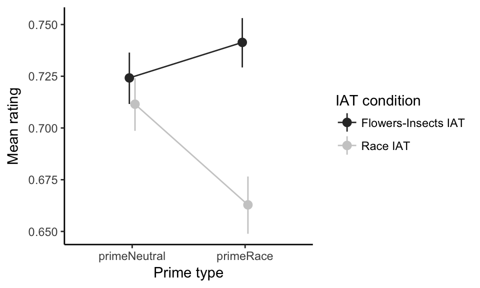

```r
ggplot(data = model_1_predicted_effects,
       aes(x = `AMP prime type`, y = fit, colour = `IAT condition`)) +
  geom_pointrange(aes(ymax = upper,
                      ymin = lower),
                  position = position_dodge(width = .1)) +
  geom_line(aes(group = `IAT condition`),
            position = position_dodge(width = .1)) +
  ylab("Mean rating") +
  xlab("Prime type") +
  scale_colour_grey() +
  theme_classic()
```

# Hypothesis test 2: Differences in self-reported ratings between contrast pair conditions

H2: Completing an IAT serves to train attitudes as well as test them. Participants who complete a race IAT will demonstrate more negative self-reported evaluations of the outgroup (black people) on the ratings than participants who completed a control (flowers-insects) IAT.

```r
ratings_data <-
  read.csv("data/processed/processed ratings data - long format.csv") %>%
  mutate(participant = as.factor(participant)) %>%
  mutate(IAT_condition = fct_relevel(as.factor(IAT_condition), "Race IAT", "Flowers-Insects IAT")) %>%
  filter(IAT_exclude_based_on_fast_trials == FALSE &
           exclude == FALSE)
```

## Linear mixed model

### Model

```r
model_2 <- lmer(rating ~ IAT_condition + modern_racism_scale_total + (1 | participant),
                contrasts = list(IAT_condition = "contr.sum"),
                data = ratings_data)
```

- Hypothesis refers to main effect for IAT condition.
- *p* values estimated via Wald method.

### Summary

```r
sjt.lmer(model_2,
         emph.p = FALSE,
         p.kr = FALSE,
         show.std = TRUE)
```

|  |  | B | CI | std. Beta | CI | p |
| --- | --- | --- | --- | --- | --- | --- |
| Fixed Parts |  |  |  |  |  |  |
| (Intercept) |  | 4.99 | 4.45 – 5.52 |  |  | <.001 |
| IAT_condition (Flowers-Insects IAT) |  | 0.10 | -0.02 – 0.22 | 0.10 | -0.01 – 0.21 | .089 |
| modern_racism_scale_total |  | -0.04 | -0.07 – -0.01 | -0.14 | -0.25 – -0.03 | .013 |
| Random Parts |  |  |  |  |  |  |
| σ<sup>2</sup> |  | 0.383 |  |  |  |  |
| τ<sub>00, participant</sub> |  | 0.673 |  |  |  |  |
| N<sub>participant</sub> |  | 212 |  |  |  |  |
| ICC<sub>participant</sub> |  | 0.637 |  |  |  |  |
| Observations |  | 1278 |  |  |  |  |
| R<sup>2</sup> / Ω<sub>0</sub><sup>2</sup> |  | .703 / .698 |  |  |  |  |

### Plot effects

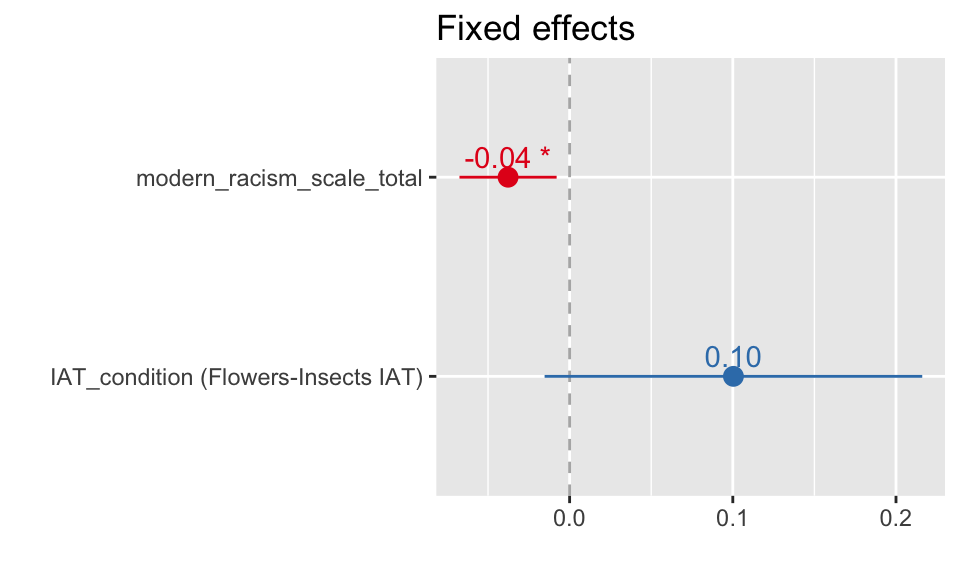

```r
sjp.lmer(model_2,
         p.kr = FALSE,
         type = "fe")
```

### Table predictions

```r
model_2_predicted_effects <- as.data.frame(effect("IAT_condition", model_2))

model_2_predicted_effects %>%
  round_df(2) %>%
  kable() %>%
  kable_styling(bootstrap_options = c("striped", "hover", "condensed"), full_width = FALSE)
```

| IAT_condition | fit | se | lower | upper |
| --- | --- | --- | --- | --- |
| Race IAT | 4.43 | 0.04 | 4.35 | 4.51 |
| Flowers-Insects IAT | 4.23 | 0.04 | 4.15 | 4.31 |

### Plot predictions

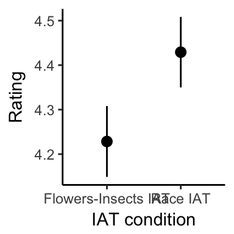

```r
ggplot(data = model_2_predicted_effects,
       aes(x = IAT_condition, y = fit)) +
  geom_pointrange(aes(ymax = upper,
                      ymin = lower)) +
  ylab("Rating") +
  xlab("IAT condition") +
  scale_colour_grey() +
  theme_classic()
```